# HW 4: Dplyr

Data 180, Professor Kennedy

Peter Guma

gumap@dickinson.edu

October 31, 2023

**Due date:** October 26 beginning of class.

Let’s get some practice with **dplyr**! For this assignment, you will work with Mario Kart data! This data is made available as part of Tidy Tuesday. A codebook is available at https://github.com/rfordatascience/tidytuesday/tree/master/data/2021/2021-05-25.

[figure not shown]

Mario Kart

First, load in dplyr. Make sure to install dplyr (or tidyverse in general) first before calling the packages. (Notice the chunk below uses warning=FALSE and message=FALSE so that unnecessary messages won’t contaminate your md output!)

For the entire assignment, make sure to use dplyr functions only. (no base R!)

```r
library(dplyr)
records <- read.csv('https://raw.githubusercontent.com/rfordatascience/tidytuesday/master/data/2021/2021-05-25/records.csv')
head(records)
```

```
##           track      type shortcut  player system_played       date time_period
## 1 Luigi Raceway Three Lap       No   Salam          NTSC 1997-02-15   2M 12.99S
## 2 Luigi Raceway Three Lap       No   Booth          NTSC 1997-02-16    2M 9.99S
## 3 Luigi Raceway Three Lap       No   Salam          NTSC 1997-02-16    2M 8.99S
## 4 Luigi Raceway Three Lap       No   Salam          NTSC 1997-02-28    2M 6.99S
## 5 Luigi Raceway Three Lap       No Gregg G          NTSC 1997-03-07    2M 4.51S
## 6 Luigi Raceway Three Lap       No Rocky G          NTSC 1997-04-30    2M 2.89S
##     time record_duration
## 1 132.99               1
## 2 129.99               0
## 3 128.99              12
## 4 126.99               7
## 5 124.51              54
## 6 122.89               0
```

```r
library(ggplot2)
```

Here are the variables included and their meanings:

- `track`: Track name
- `type`: Single or three lap record
- `shortcut`: Shortcut or non-shortcut record
- `player`: Player’s name
- `system_played`: Used system (NTSC or PAL)
- `date`: World record date
- `time_period`: Time as hms period
- `time`: Time in seconds
- `record_duration`: Record duration in days

# Question 1

For the entire data, display the summary statistics (mean, median, mode, etc.) using the dplyr function `summary()` via pipe.

```r
records %>% summary()
```

```
##     track               type             shortcut            player
##  Length:2334        Length:2334        Length:2334        Length:2334
##  Class :character   Class :character   Class :character   Class :character
##  Mode  :character   Mode  :character   Mode  :character   Mode  :character
##
##
##
##  system_played          date           time_period             time
##  Length:2334        Length:2334        Length:2334        Min.   : 14.59
##  Class :character   Class :character   Class :character   1st Qu.: 39.03
##  Mode  :character   Mode  :character   Mode  :character   Median : 86.19
##                                                           Mean   : 90.62
##                                                           3rd Qu.:120.16
##                                                           Max.   :375.83
##  record_duration
##  Min.   :   0.0
##  1st Qu.:   6.0
##  Median :  51.0
##  Mean   : 220.8
##  3rd Qu.: 198.8
##  Max.   :3659.0
```

# Question 2

Return the count of cases where a record was broken in more than a year (365 days).

```r
count <- records %>%
  filter(record_duration > 365) %>%
  nrow()
count #should return 410
```

```
## [1] 410
```

# Question 3

Return name of the player, name of the track, record date, and record duration for the record that took the longest time to be broken.

```r
longest <- max(records$record_duration)
filter(records, record_duration==longest) %>%
  select(player, track, date, record_duration)
```

```
##   player        track       date record_duration
## 1 Alex G Yoshi Valley 2010-11-27            3659
```

# Question 4

Return the mean record time (`time`) by each track. What is the name of the track with the fastest average record time? *Hint: you should use `group_by() and summarize()*

```r
mean_times_by_track <- records %>%
  group_by(track) %>%
  summarize(mean(time))
mean_times_by_track
```

```
## # A tibble: 16 × 2
##    track                 `mean(time)`
##    <chr>                        <dbl>
##  1 Banshee Boardwalk             97.4
##  2 Bowser's Castle               96.2
##  3 Choco Mountain                70.8
##  4 D.K.'s Jungle Parkway         71.0
##  5 Frappe Snowland               58.6
##  6 Kalimari Desert               76.9
##  7 Koopa Troopa Beach            72.4
##  8 Luigi Raceway                 74.3
##  9 Mario Raceway                 54.2
## 10 Moo Moo Farm                  61.1
## 11 Rainbow Road                 205.
## 12 Royal Raceway                109.
## 13 Sherbet Land                  78.1
## 14 Toad's Turnpike               98.9
## 15 Wario Stadium                132.
## 16 Yoshi Valley                  55.6
```

```r
min_mean_time <- mean_times_by_track$`mean(time)` %>%
  min()
min_mean_time
```

```
## [1] 54.19588
```

```r
# I left in some old code for future reference even though it doesn't work
 # max_track_by_time <- mean_times %>%
  # filter(mean_times$mean(time)==max_mean_time)
 # max_track_by_time
 # select(mean_times$`mean(time)` == max(mean_times$`mean(time)`))
 # summarize(mean_times, mean_times$`mean(time)` == max(mean_times))
 # select(filter(mean_times, mean_time == max(mean_times$`mean(time)`)))
 # filter(mean_times, mean(time) == min(mean_times$`mean(time)`)) #???
 # select(mean_times, track)
 # select(mean_times)
```

# Question 5

Let’s get the year from the `date` column and save it as a variable named `year`. You can use the function `substr(date, 1, 4)` which grabs the first 4 digits in the `date` column. Use this expression in `mutate()` to create a `year` column. (Don’t forget to save/overwrite the dataframe returned to the original one!)

```r
year <- records$date %>%
 substr(1, 4)
records <- mutate(records, year)
# records #omitted to save space in knit
```

# Question 6

Now get the average record time (`time`) by year.

```r
mean_times_by_year <- records %>%
  group_by(year) %>%
  summarize(mean = mean(time))
mean_times_by_year
```

```
## # A tibble: 25 × 2
##    year   mean
##    <chr> <dbl>
##  1 1997   93.3
##  2 1998   93.7
##  3 1999   87.7
##  4 2000   77.3
##  5 2001   92.8
##  6 2002   92.2
##  7 2003   83.1
##  8 2004   99.6
##  9 2005   90.5
## 10 2006  105.
## # ℹ 15 more rows
```

# Question 7

Continuing with your results in Question 6: Do you notice a trend across years? Are the record times getting faster, slower, or no clear pattern in time? Create a barplot where each year appears on the x axis (you can treat year as a categorical variable in this case) and y axis showing the mean record time in each year. Interpret your graph. *Hint: Use your code in Question 6, which returns the average record times by year, followed by `%>% ggplot(aes(year,mean)) + geom_bar(stat='identity')` Hint2: To make your figure wider, you can insert fig.width=10 inside the curly brackets at the beginning of your r code chunk below, as {r, fig.width=10} which I already did for you below,*

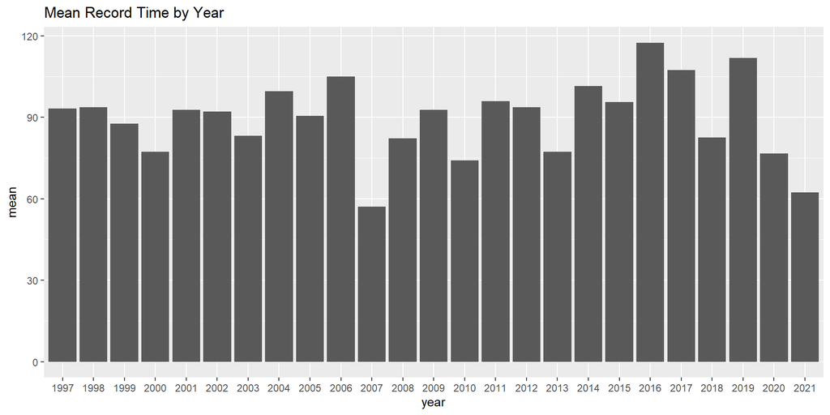

```r
mean_times_by_year %>%
 ggplot(aes(year, mean)) +
 geom_bar(stat='identity') + labs(title="Mean Record Time by Year")
```

# Question 8

Create two overlaid histograms by `type` on the same plot where each histogram shows the distribution of `time` for a given track `type`. Combine dplyr and ggplot2 to achieve this. How do record times compare between Single Lap and Three Lap tracks? Hint: use `records %>% dplyr functions %>% ggplot(., aes()) + type of ggplot plot` to combine dpylr with ggplot. Note that the dot inside `ggplot()` is a placeholder for `records`, as dplyr has already pulled `records` df at the beginning of the code (making it unnecessary to type it twice!)

Note: Set `alpha=.5` for transparency.

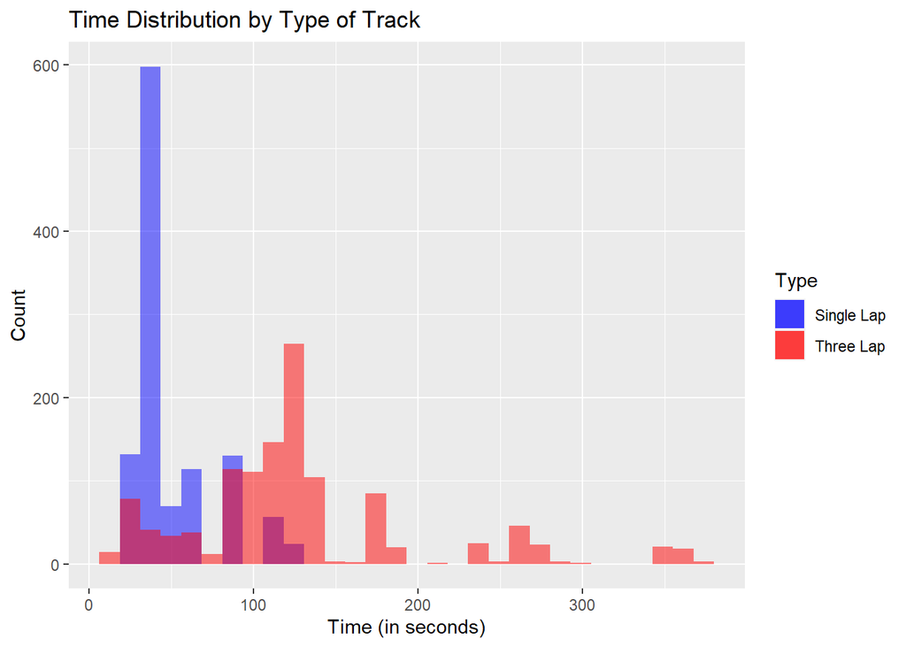

```r
#single_laps <- filter(records, type=="Single Lap")
#three_laps <- filter(records, type=="Three Lap")
records %>%
  group_by(type) %>%
  ggplot(., aes(time)) +
  geom_histogram(data=filter(records, type=="Single Lap"), aes(fill=type), bins=30, alpha=.5) +
  geom_histogram(data=filter(records, type=="Three Lap"), aes(fill=type), bins=30, alpha=.5) + scale_fill_manual(name="Type", values=c("blue", "red"), labels=c("Single Lap", "Three Lap")) +
  labs(x="Time (in seconds)", y="Count", title="Time Distribution by Type of Track")
```

```r
#  geom_histogram(stat='identity', bins=50, alpha=.5) +
#  scale_x_discrete(label=function(x) stringr::str_trunc(x,10))
```

Record times for Three Lap tracks are typically much longer than those for Single Lap tracks; this makes sense because completing more laps usually implies a longer game. However, their bins do overlap, and the smallest bin on the histogram only contains data from Three Laps. Three Lap tracks also have a much wider range of observed times, whereas the times for Single Lap tracks are mostly under 100 seconds.

# Question 9

Three Lap time reports the total time spent finishing three laps in total, as opposed to finishing a single lap. Let’s divide all time observations with `type=="Three Lap"` by 3 to check whether **per lap** performance declines across Three Lap vs. Single Lap. Generate a new variable named `time_per` which is the time spent per round, and create two overlaid histograms of `type_per` by `type`. Hint: Use `mutate()`, and inside `mutate()` use `ifelse()` function to conditionally replace rows: e.g.., `ifelse(type=="Three Lap",time/3,time)` which divides `time` by three only if `type=="Three Lap"`.

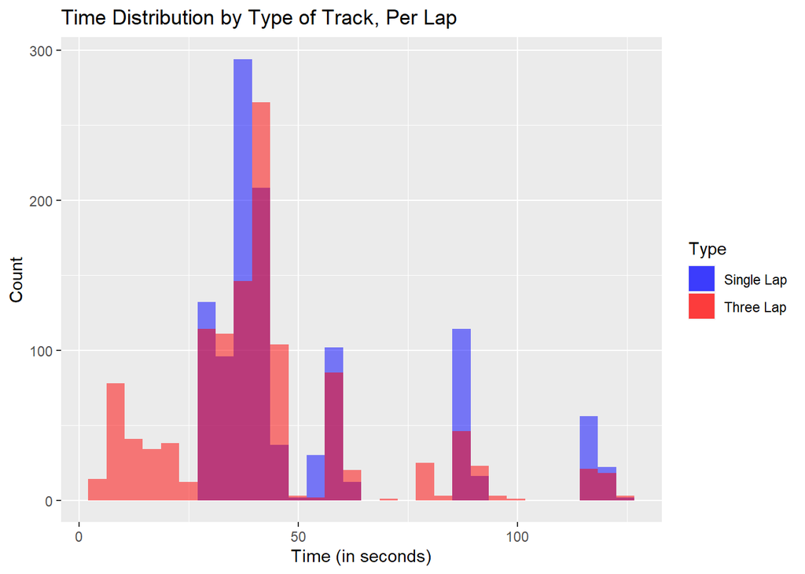

```r
new_records <- mutate(records, time_per=ifelse(type=="Three Lap", time/3, time))

new_records %>%
  group_by(type) %>%
  ggplot(., aes(time_per)) +
  geom_histogram(data=filter(new_records, type=="Single Lap"), aes(fill=type), bins=30, alpha=.5) +
  geom_histogram(data=filter(new_records, type=="Three Lap"), aes(fill=type), bins=30, alpha=.5) + scale_fill_manual(name="Type", values=c("blue", "red"), labels=c("Single Lap", "Three Lap")) +
  labs(x="Time (in seconds)", y="Count", title="Time Distribution by Type of Track, Per Lap")
```

# Question 10 There appears to be recent discoveries of shortcuts within some of the tracks causing a number of extraordinarily fast records set in `Three Lap` tracks (Have you noticed this in your graph in Question 9?). Replicate your histogram in Question 9 with `shortcut=="No"` filter.

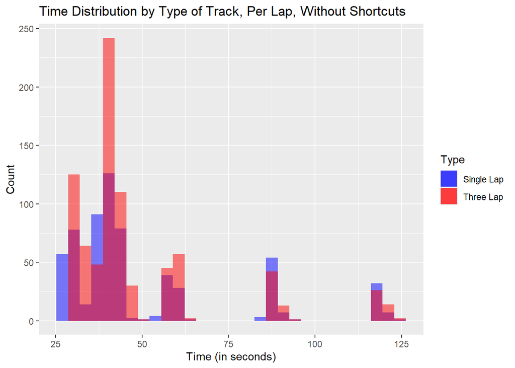

```r
new_records %>%
  group_by(type) %>%
  ggplot(., aes(time_per)) +
  geom_histogram(data=filter(new_records, type=="Single Lap", shortcut=="No"), aes(fill=type), bins=30, alpha=.5) +
  geom_histogram(data=filter(new_records, type=="Three Lap", shortcut=="No"), aes(fill=type), bins=30, alpha=.5) + scale_fill_manual(name="Type", values=c("blue", "red"), labels=c("Single Lap", "Three Lap")) +
  labs(x="Time (in seconds)", y="Count", title="Time Distribution by Type of Track, Per Lap, Without Shortcuts")
```

# Question 11

Lastly, compare the mean `time` by `system_played`. Do you observe a difference across the two game systems? (Note: NTSC version of the game runs at 60 FPS (Frames Per Second), and PAL runs at 50 FPS!) Does this appear to affect performance of records set?

```r
mean(filter(records, system_played=="NTSC")$time)
```

```
## [1] 79.93683
```

```r
mean(filter(records, system_played=="PAL")$time)
```

```
## [1] 95.15553
```

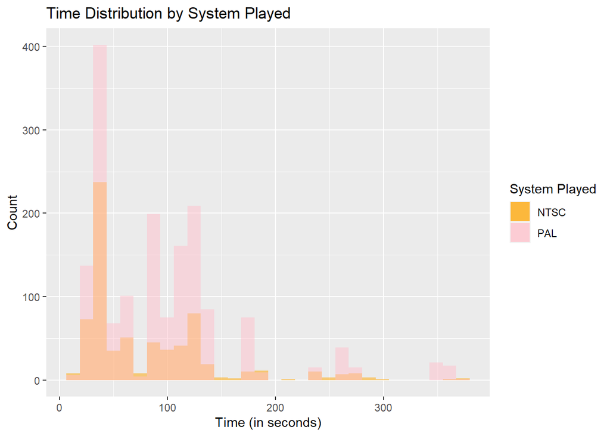

```r
records %>%
  ggplot(., aes(time)) +
  geom_histogram(data=filter(records, system_played=="NTSC"), aes(fill=system_played), bins=30, alpha=.5) +
  geom_histogram(data=filter(records, system_played=="PAL"), aes(fill=system_played), bins=30, alpha=.5) + scale_fill_manual(name="System Played", values=c("orange", "pink"), labels=c("NTSC", "PAL")) +
  labs(x="Time (in seconds)", y="Count", title="Time Distribution by System Played")
```

Yes, NTSC has a mean time of 79.93683 seconds, whereas PAL’s mean time is 95.15553 seconds. We can see from the histogram that this affects performance of records set, as only NTSC users have achieved times in the fastest bin. At the same time, PAL appears to be a more popular system, so a larger proportion of the records are PAL than NTSC. Both are well suited to breaking records.

You are done! 🏁 Don’t forget to commit and push your .Rmd file to your Github repository before the due date. (Well… the checkered flag emoji is now super relevant for this assignment!)